# Exercise Session 1

Justin Noel

10/27/2017

## ISLR Exercise 8

Although we could use the ISLR package. We will download the [dataset](http://www-bcf.usc.edu/~gareth/ISL/College.csv) into our local directory.

```r
download.file("http://www-bcf.usc.edu/~gareth/ISL/College.csv", "College.csv")
```

Load our data frame from the file.

```r
df <- read.csv("College.csv")
```

Let’s look at it:

```r
head(df)
```

```
##                              X Private Apps Accept Enroll Top10perc
## 1 Abilene Christian University     Yes 1660   1232    721        23
## 2           Adelphi University     Yes 2186   1924    512        16
## 3               Adrian College     Yes 1428   1097    336        22
## 4          Agnes Scott College     Yes  417    349    137        60
## 5    Alaska Pacific University     Yes  193    146     55        16
## 6            Albertson College     Yes  587    479    158        38
##   Top25perc F.Undergrad P.Undergrad Outstate Room.Board Books Personal PhD
## 1        52        2885         537     7440       3300   450     2200  70
## 2        29        2683        1227    12280       6450   750     1500  29
## 3        50        1036          99    11250       3750   400     1165  53
## 4        89         510          63    12960       5450   450      875  92
## 5        44         249         869     7560       4120   800     1500  76
## 6        62         678          41    13500       3335   500      675  67
##   Terminal S.F.Ratio perc.alumni Expend Grad.Rate
## 1       78      18.1          12   7041        60
## 2       30      12.2          16  10527        56
## 3       66      12.9          30   8735        54
## 4       97       7.7          37  19016        59
## 5       72      11.9           2  10922        15
## 6       73       9.4          11   9727        55
```

```r
summary(df)
```

```
##                             X       Private        Apps
##  Abilene Christian University:  1   No :212   Min.   :   81
##  Adelphi University          :  1   Yes:565   1st Qu.:  776
##  Adrian College              :  1             Median : 1558
##  Agnes Scott College         :  1             Mean   : 3002
##  Alaska Pacific University   :  1             3rd Qu.: 3624
##  Albertson College           :  1             Max.   :48094
##  (Other)                     :771
##      Accept          Enroll       Top10perc       Top25perc
##  Min.   :   72   Min.   :  35   Min.   : 1.00   Min.   :  9.0
##  1st Qu.:  604   1st Qu.: 242   1st Qu.:15.00   1st Qu.: 41.0
##  Median : 1110   Median : 434   Median :23.00   Median : 54.0
##  Mean   : 2019   Mean   : 780   Mean   :27.56   Mean   : 55.8
##  3rd Qu.: 2424   3rd Qu.: 902   3rd Qu.:35.00   3rd Qu.: 69.0
##  Max.   :26330   Max.   :6392   Max.   :96.00   Max.   :100.0
##
##   F.Undergrad     P.Undergrad         Outstate       Room.Board
##  Min.   :  139   Min.   :    1.0   Min.   : 2340   Min.   :1780
##  1st Qu.:  992   1st Qu.:   95.0   1st Qu.: 7320   1st Qu.:3597
##  Median : 1707   Median :  353.0   Median : 9990   Median :4200
##  Mean   : 3700   Mean   :  855.3   Mean   :10441   Mean   :4358
##  3rd Qu.: 4005   3rd Qu.:  967.0   3rd Qu.:12925   3rd Qu.:5050
##  Max.   :31643   Max.   :21836.0   Max.   :21700   Max.   :8124
##
##      Books           Personal         PhD            Terminal
##  Min.   :  96.0   Min.   : 250   Min.   :  8.00   Min.   : 24.0
##  1st Qu.: 470.0   1st Qu.: 850   1st Qu.: 62.00   1st Qu.: 71.0
##  Median : 500.0   Median :1200   Median : 75.00   Median : 82.0
##  Mean   : 549.4   Mean   :1341   Mean   : 72.66   Mean   : 79.7
##  3rd Qu.: 600.0   3rd Qu.:1700   3rd Qu.: 85.00   3rd Qu.: 92.0
##  Max.   :2340.0   Max.   :6800   Max.   :103.00   Max.   :100.0
##
##    S.F.Ratio      perc.alumni        Expend        Grad.Rate
##  Min.   : 2.50   Min.   : 0.00   Min.   : 3186   Min.   : 10.00
##  1st Qu.:11.50   1st Qu.:13.00   1st Qu.: 6751   1st Qu.: 53.00
##  Median :13.60   Median :21.00   Median : 8377   Median : 65.00
##  Mean   :14.09   Mean   :22.74   Mean   : 9660   Mean   : 65.46
##  3rd Qu.:16.50   3rd Qu.:31.00   3rd Qu.:10830   3rd Qu.: 78.00
##  Max.   :39.80   Max.   :64.00   Max.   :56233   Max.   :118.00
##
```

Uh oh. We can see that the college names have been converted into factors. This is not especially helpful. Let’s make these into the names of the rows.

```r
rownames(df) <- df[,1]
head(df)
```

```
##                                                         X Private Apps
## Abilene Christian University Abilene Christian University     Yes 1660
## Adelphi University                     Adelphi University     Yes 2186
## Adrian College                             Adrian College     Yes 1428
## Agnes Scott College                   Agnes Scott College     Yes  417
## Alaska Pacific University       Alaska Pacific University     Yes  193
## Albertson College                       Albertson College     Yes  587
##                              Accept Enroll Top10perc Top25perc F.Undergrad
## Abilene Christian University   1232    721        23        52        2885
## Adelphi University             1924    512        16        29        2683
## Adrian College                 1097    336        22        50        1036
## Agnes Scott College             349    137        60        89         510
## Alaska Pacific University       146     55        16        44         249
## Albertson College               479    158        38        62         678
##                              P.Undergrad Outstate Room.Board Books
## Abilene Christian University         537     7440       3300   450
## Adelphi University                  1227    12280       6450   750
## Adrian College                        99    11250       3750   400
## Agnes Scott College                   63    12960       5450   450
## Alaska Pacific University            869     7560       4120   800
## Albertson College                     41    13500       3335   500
##                              Personal PhD Terminal S.F.Ratio perc.alumni
## Abilene Christian University     2200  70       78      18.1          12
## Adelphi University               1500  29       30      12.2          16
## Adrian College                   1165  53       66      12.9          30
## Agnes Scott College               875  92       97       7.7          37
## Alaska Pacific University        1500  76       72      11.9           2
## Albertson College                 675  67       73       9.4          11
##                              Expend Grad.Rate
## Abilene Christian University   7041        60
## Adelphi University            10527        56
## Adrian College                 8735        54
## Agnes Scott College           19016        59
## Alaska Pacific University     10922        15
## Albertson College              9727        55
```

```r
summary(df)
```

```
##                             X       Private        Apps
##  Abilene Christian University:  1   No :212   Min.   :   81
##  Adelphi University          :  1   Yes:565   1st Qu.:  776
##  Adrian College              :  1             Median : 1558
##  Agnes Scott College         :  1             Mean   : 3002
##  Alaska Pacific University   :  1             3rd Qu.: 3624
##  Albertson College           :  1             Max.   :48094
##  (Other)                     :771
##      Accept          Enroll       Top10perc       Top25perc
##  Min.   :   72   Min.   :  35   Min.   : 1.00   Min.   :  9.0
##  1st Qu.:  604   1st Qu.: 242   1st Qu.:15.00   1st Qu.: 41.0
##  Median : 1110   Median : 434   Median :23.00   Median : 54.0
##  Mean   : 2019   Mean   : 780   Mean   :27.56   Mean   : 55.8
##  3rd Qu.: 2424   3rd Qu.: 902   3rd Qu.:35.00   3rd Qu.: 69.0
##  Max.   :26330   Max.   :6392   Max.   :96.00   Max.   :100.0
##
##   F.Undergrad     P.Undergrad         Outstate       Room.Board
##  Min.   :  139   Min.   :    1.0   Min.   : 2340   Min.   :1780
##  1st Qu.:  992   1st Qu.:   95.0   1st Qu.: 7320   1st Qu.:3597
##  Median : 1707   Median :  353.0   Median : 9990   Median :4200
##  Mean   : 3700   Mean   :  855.3   Mean   :10441   Mean   :4358
##  3rd Qu.: 4005   3rd Qu.:  967.0   3rd Qu.:12925   3rd Qu.:5050
##  Max.   :31643   Max.   :21836.0   Max.   :21700   Max.   :8124
##
##      Books           Personal         PhD            Terminal
##  Min.   :  96.0   Min.   : 250   Min.   :  8.00   Min.   : 24.0
##  1st Qu.: 470.0   1st Qu.: 850   1st Qu.: 62.00   1st Qu.: 71.0
##  Median : 500.0   Median :1200   Median : 75.00   Median : 82.0
##  Mean   : 549.4   Mean   :1341   Mean   : 72.66   Mean   : 79.7
##  3rd Qu.: 600.0   3rd Qu.:1700   3rd Qu.: 85.00   3rd Qu.: 92.0
##  Max.   :2340.0   Max.   :6800   Max.   :103.00   Max.   :100.0
##
##    S.F.Ratio      perc.alumni        Expend        Grad.Rate
##  Min.   : 2.50   Min.   : 0.00   Min.   : 3186   Min.   : 10.00
##  1st Qu.:11.50   1st Qu.:13.00   1st Qu.: 6751   1st Qu.: 53.00
##  Median :13.60   Median :21.00   Median : 8377   Median : 65.00
##  Mean   :14.09   Mean   :22.74   Mean   : 9660   Mean   : 65.46
##  3rd Qu.:16.50   3rd Qu.:31.00   3rd Qu.:10830   3rd Qu.: 78.00
##  Max.   :39.80   Max.   :64.00   Max.   :56233   Max.   :118.00
##
```

We are supposed to use the fix command. Let’s see what that is.

```r
?fix
```

Okay, that was not especially helpful. Let’s run it.

```r
fix(df)
```

I see. This gives me an incredibly ugly data frame editor.

Okay let’s get rid of the unneccessary column.

```r
df <- df[,-1]
```

Note that the “-1” here means that we will select all of the columns except the first one. This behavior is different from python where -1 will typically refer to the last column and -2 will refer to the second to last column.

Let’s see this in our ugly editor again.

```r
fix(df)
```

Okay, let’s look at our cleaned data frame:

```r
summary(df)
```

```
##  Private        Apps           Accept          Enroll       Top10perc
##  No :212   Min.   :   81   Min.   :   72   Min.   :  35   Min.   : 1.00
##  Yes:565   1st Qu.:  776   1st Qu.:  604   1st Qu.: 242   1st Qu.:15.00
##            Median : 1558   Median : 1110   Median : 434   Median :23.00
##            Mean   : 3002   Mean   : 2019   Mean   : 780   Mean   :27.56
##            3rd Qu.: 3624   3rd Qu.: 2424   3rd Qu.: 902   3rd Qu.:35.00
##            Max.   :48094   Max.   :26330   Max.   :6392   Max.   :96.00
##    Top25perc      F.Undergrad     P.Undergrad         Outstate
##  Min.   :  9.0   Min.   :  139   Min.   :    1.0   Min.   : 2340
##  1st Qu.: 41.0   1st Qu.:  992   1st Qu.:   95.0   1st Qu.: 7320
##  Median : 54.0   Median : 1707   Median :  353.0   Median : 9990
##  Mean   : 55.8   Mean   : 3700   Mean   :  855.3   Mean   :10441
##  3rd Qu.: 69.0   3rd Qu.: 4005   3rd Qu.:  967.0   3rd Qu.:12925
##  Max.   :100.0   Max.   :31643   Max.   :21836.0   Max.   :21700
##    Room.Board       Books           Personal         PhD
##  Min.   :1780   Min.   :  96.0   Min.   : 250   Min.   :  8.00
##  1st Qu.:3597   1st Qu.: 470.0   1st Qu.: 850   1st Qu.: 62.00
##  Median :4200   Median : 500.0   Median :1200   Median : 75.00
##  Mean   :4358   Mean   : 549.4   Mean   :1341   Mean   : 72.66
##  3rd Qu.:5050   3rd Qu.: 600.0   3rd Qu.:1700   3rd Qu.: 85.00
##  Max.   :8124   Max.   :2340.0   Max.   :6800   Max.   :103.00
##     Terminal       S.F.Ratio      perc.alumni        Expend
##  Min.   : 24.0   Min.   : 2.50   Min.   : 0.00   Min.   : 3186
##  1st Qu.: 71.0   1st Qu.:11.50   1st Qu.:13.00   1st Qu.: 6751
##  Median : 82.0   Median :13.60   Median :21.00   Median : 8377
##  Mean   : 79.7   Mean   :14.09   Mean   :22.74   Mean   : 9660
##  3rd Qu.: 92.0   3rd Qu.:16.50   3rd Qu.:31.00   3rd Qu.:10830
##  Max.   :100.0   Max.   :39.80   Max.   :64.00   Max.   :56233
##    Grad.Rate
##  Min.   : 10.00
##  1st Qu.: 53.00
##  Median : 65.00
##  Mean   : 65.46
##  3rd Qu.: 78.00
##  Max.   :118.00
```

Good, the unnecessary factor data is gone and apparently some school has an awful graduation rate.

Which one is it?

```r
which.min(df$Grad.Rate)
```

```
## [1] 586
```

Who is this culprit:

```r
df[586,]
```

```
##                           Private Apps Accept Enroll Top10perc Top25perc
## Texas Southern University      No 4345   3245   2604        15        85
##                           F.Undergrad P.Undergrad Outstate Room.Board
## Texas Southern University        5584        3101     7860       3360
##                           Books Personal PhD Terminal S.F.Ratio
## Texas Southern University   600     1700  65       75      18.2
##                           perc.alumni Expend Grad.Rate
## Texas Southern University          21   3605        10
```

Wow, we should avoid Texas Southern University.

Now, let us look at a pairwise scatterplot of the first ten columns.

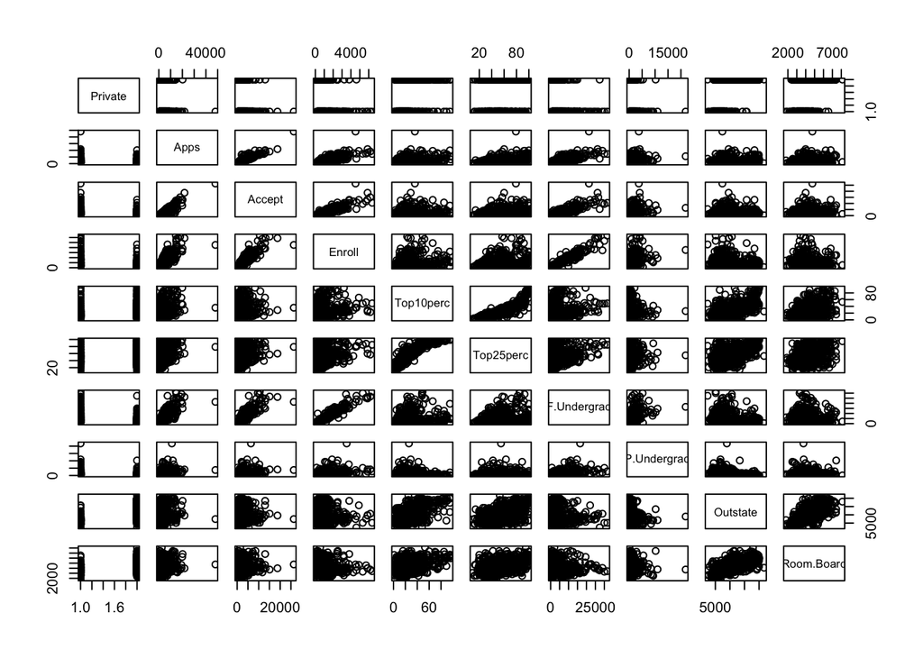

```r
pairs(df[,1:10])
```

That was ugly. Let’s try this again.

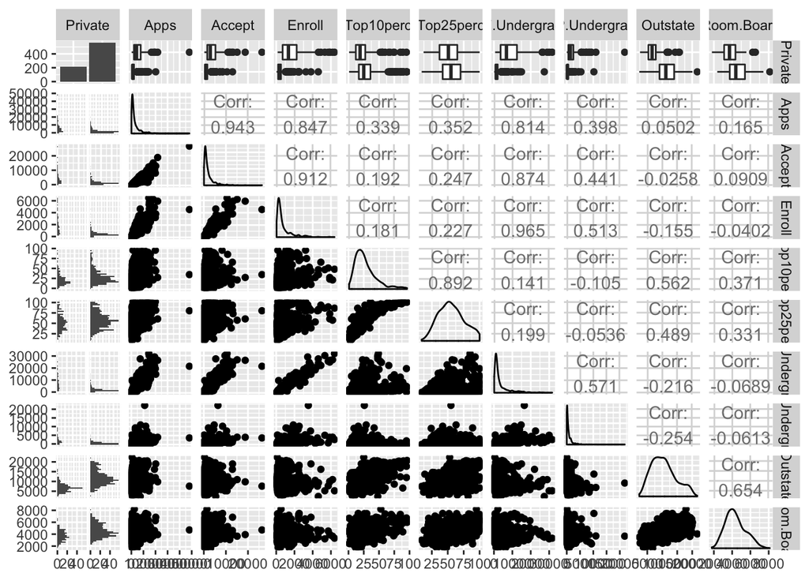

```r
library(GGally)
ggpairs(df[,1:10])
```

Now let us construct a boxplot:

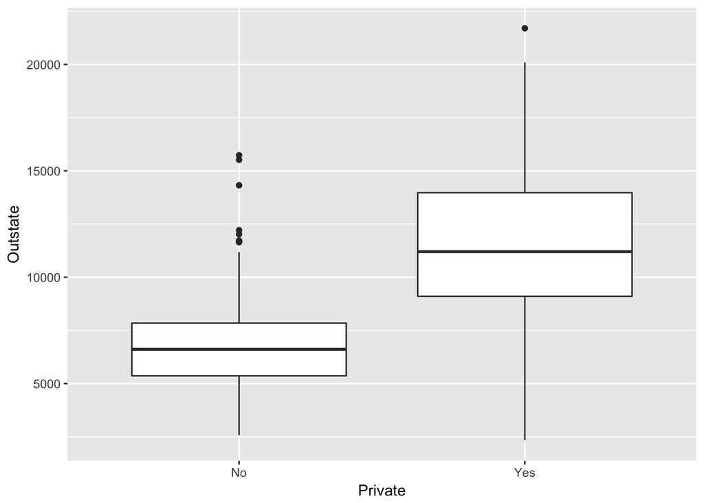

```r
library(ggplot2)
ggplot(df, aes(y = Outstate, x = Private)) + geom_boxplot()
```

Okay, let us construct a new Elite feature which indicates if more than half of the students come from the top 10% of their class. First populate the entries.

```r
Elite = rep("No", nrow(df))
```

Mark the elite schools:

```r
Elite[df$Top10perc > 50]="Yes"
```

Make these strings factors:

```r
Elite=as.factor(Elite)
```

Add to our data frame.

```r
df$Elite = Elite
colnames(df)
```

```
##  [1] "Private"     "Apps"        "Accept"      "Enroll"      "Top10perc"
##  [6] "Top25perc"   "F.Undergrad" "P.Undergrad" "Outstate"    "Room.Board"
## [11] "Books"       "Personal"    "PhD"         "Terminal"    "S.F.Ratio"
## [16] "perc.alumni" "Expend"      "Grad.Rate"   "Elite"
```

Okay check the new summary:

```r
summary(df)
```

```
##  Private        Apps           Accept          Enroll       Top10perc
##  No :212   Min.   :   81   Min.   :   72   Min.   :  35   Min.   : 1.00
##  Yes:565   1st Qu.:  776   1st Qu.:  604   1st Qu.: 242   1st Qu.:15.00
##            Median : 1558   Median : 1110   Median : 434   Median :23.00
##            Mean   : 3002   Mean   : 2019   Mean   : 780   Mean   :27.56
##            3rd Qu.: 3624   3rd Qu.: 2424   3rd Qu.: 902   3rd Qu.:35.00
##            Max.   :48094   Max.   :26330   Max.   :6392   Max.   :96.00
##    Top25perc      F.Undergrad     P.Undergrad         Outstate
##  Min.   :  9.0   Min.   :  139   Min.   :    1.0   Min.   : 2340
##  1st Qu.: 41.0   1st Qu.:  992   1st Qu.:   95.0   1st Qu.: 7320
##  Median : 54.0   Median : 1707   Median :  353.0   Median : 9990
##  Mean   : 55.8   Mean   : 3700   Mean   :  855.3   Mean   :10441
##  3rd Qu.: 69.0   3rd Qu.: 4005   3rd Qu.:  967.0   3rd Qu.:12925
##  Max.   :100.0   Max.   :31643   Max.   :21836.0   Max.   :21700
##    Room.Board       Books           Personal         PhD
##  Min.   :1780   Min.   :  96.0   Min.   : 250   Min.   :  8.00
##  1st Qu.:3597   1st Qu.: 470.0   1st Qu.: 850   1st Qu.: 62.00
##  Median :4200   Median : 500.0   Median :1200   Median : 75.00
##  Mean   :4358   Mean   : 549.4   Mean   :1341   Mean   : 72.66
##  3rd Qu.:5050   3rd Qu.: 600.0   3rd Qu.:1700   3rd Qu.: 85.00
##  Max.   :8124   Max.   :2340.0   Max.   :6800   Max.   :103.00
##     Terminal       S.F.Ratio      perc.alumni        Expend
##  Min.   : 24.0   Min.   : 2.50   Min.   : 0.00   Min.   : 3186
##  1st Qu.: 71.0   1st Qu.:11.50   1st Qu.:13.00   1st Qu.: 6751
##  Median : 82.0   Median :13.60   Median :21.00   Median : 8377
##  Mean   : 79.7   Mean   :14.09   Mean   :22.74   Mean   : 9660
##  3rd Qu.: 92.0   3rd Qu.:16.50   3rd Qu.:31.00   3rd Qu.:10830
##  Max.   :100.0   Max.   :39.80   Max.   :64.00   Max.   :56233
##    Grad.Rate      Elite
##  Min.   : 10.00   No :699
##  1st Qu.: 53.00   Yes: 78
##  Median : 65.00
##  Mean   : 65.46
##  3rd Qu.: 78.00
##  Max.   :118.00
```

Looks good. Now let us check out the out-of-state numbers for elite schools.

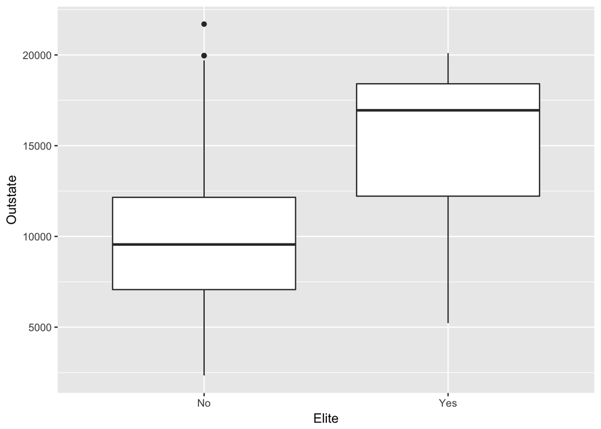

```r
ggplot(df, aes(x=Elite, y=Outstate)) + geom_boxplot()
```

Let us check this out side by side:

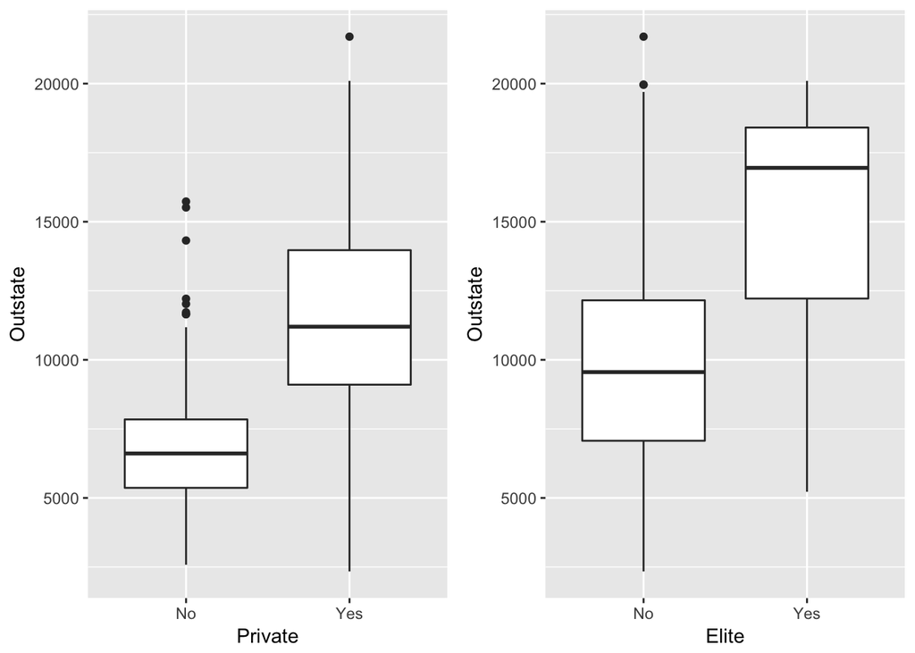

```r
p1 <- ggplot(df, aes(x = Private, y = Outstate)) + geom_boxplot()
p2 <- ggplot(df, aes(x = Elite, y = Outstate)) + geom_boxplot()
library(ggpubr)
ggarrange(p1, p2)
```

Cool.

Let’s check out some more distributions.

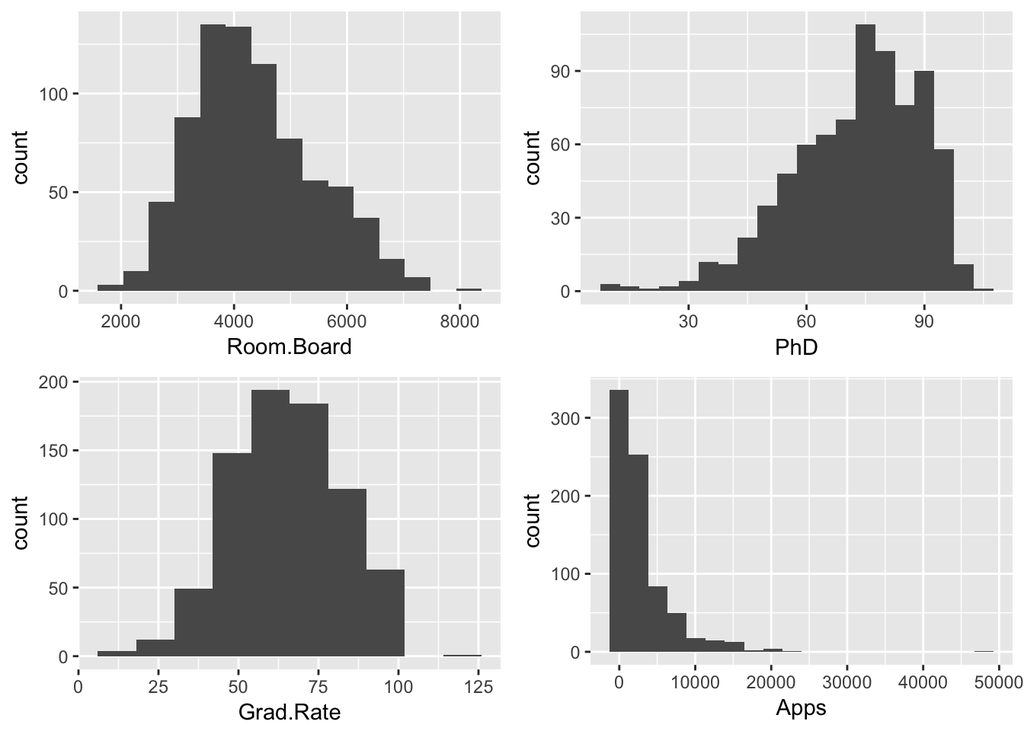

```r
p1 <- ggplot(df, aes(x = Room.Board)) + geom_histogram(bins = 15)

p2 <- ggplot(df, aes(x = PhD)) + geom_histogram(bins = 20)

p3 <- ggplot(df, aes(x = Grad.Rate)) + geom_histogram(bins = 10)

p4 <- ggplot(df, aes(x = Apps)) + geom_histogram(bins = 20)
ggarrange(p1, p2, p3, p4, ncol = 2, nrow = 2)
```

Finally let’s check out how many applications Elite schools get:

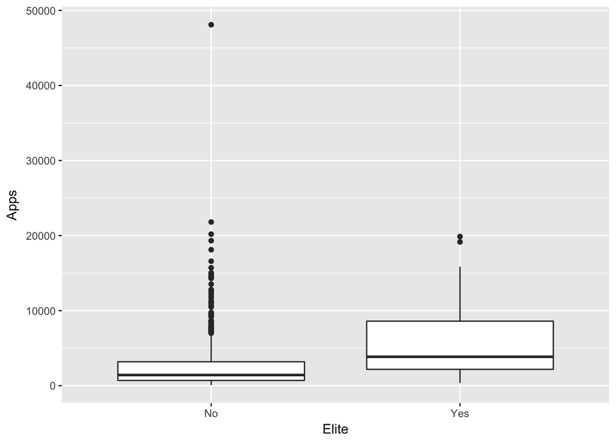

```r
ggplot(df, aes(x = Elite, y = Apps)) + geom_boxplot()
```

Wow, who is that outlier?

```r
df[which.max(df$Apps),]
```

```
##                          Private  Apps Accept Enroll Top10perc Top25perc
## Rutgers at New Brunswick      No 48094  26330   4520        36        79
##                          F.Undergrad P.Undergrad Outstate Room.Board Books
## Rutgers at New Brunswick       21401        3712     7410       4748   690
##                          Personal PhD Terminal S.F.Ratio perc.alumni
## Rutgers at New Brunswick     2009  90       95      19.5          19
##                          Expend Grad.Rate Elite
## Rutgers at New Brunswick  10474        77    No
```

What is going on there?

### Some fun

Let us clear our workspace.

```r
rm(list = ls())
```

Okay, I have grown a little tired of R’s built in idioscyncracies. I am going to try and work in the tidyverse.

Let us load a [spooky dataset](https://www.kaggle.com/c/spooky-author-identification):

```r
library(tidyverse)
spooky <- read_csv("train.csv")
head(spooky)
```

```
## # A tibble: 6 x 3
##        id
##     <chr>
## 1 id26305
## 2 id17569
## 3 id11008
## 4 id27763
## 5 id12958
## 6 id22965
## # ... with 2 more variables: text <chr>, author <chr>
```

Okay let us clean this up.

```r
spooky = spooky[,-1]
spooky$author <- as.factor(spooky$author)
head(spooky)
```

```
## # A tibble: 6 x 2
##                                                                          text
##                                                                         <chr>
## 1 This process, however, afforded me no means of ascertaining the dimensions
## 2     It never once occurred to me that the fumbling might be a mere mistake.
## 3 In his left hand was a gold snuff box, from which, as he capered down the h
## 4 How lovely is spring As we looked from Windsor Terrace on the sixteen ferti
## 5 Finding nothing else, not even gold, the Superintendent abandoned his attem
## 6 A youth passed in solitude, my best years spent under your gentle and femin
## # ... with 1 more variables: author <fctr>
```

We are going to manipulate some text, so let us load stringr (this is unnecessary after loading tidyverse).

```r
library(stringr)
?stringr
```

Now let us check the use of punctuation.

```r
spooky$commas = str_count(spooky$text, ",")
spooky$exclam = str_count(spooky$text, "!")
spooky$quest = str_count(spooky$text, "\\?")
```

A summary:

```r
summary(spooky)
```

```
##      text           author         commas           exclam
##  Length:19579       EAP:7900   Min.   : 0.000   Min.   :0
##  Class :character   HPL:5635   1st Qu.: 1.000   1st Qu.:0
##  Mode  :character   MWS:6044   Median : 1.000   Median :0
##                                Mean   : 1.952   Mean   :0
##                                3rd Qu.: 3.000   3rd Qu.:0
##                                Max.   :48.000   Max.   :0
##      quest
##  Min.   :0.00000
##  1st Qu.:0.00000
##  Median :0.00000
##  Mean   :0.05608
##  3rd Qu.:0.00000
##  Max.   :4.00000
```

```r
spooky %>% filter(commas == max(commas))
```

```
## # A tibble: 1 x 5
##                                                                          text
##                                                                         <chr>
## 1 "To chambers of painted state farewell To midnight revelry, and the panting
## # ... with 4 more variables: author <fctr>, commas <int>, exclam <int>,
## #   quest <int>
```

Okay so exclamation points are no help:

```r
spooky = spooky %>% select(-exclam)
```

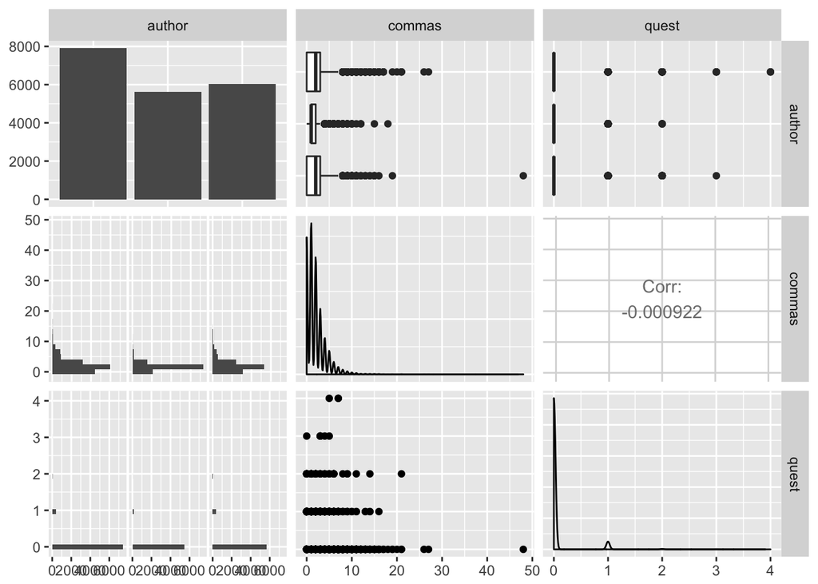

```r
ggpairs(spooky %>% select(-text))
```

```r
library(tm)
?Corpus
corp <- Corpus(VectorSource(spooky$text))
inspect(corp[[1]])
```

```
## <<PlainTextDocument>>
## Metadata:  7
## Content:  chars: 231
##
## This process, however, afforded me no means of ascertaining the dimensions of my dungeon; as I might make its circuit, and return to the point whence I set out, without being aware of the fact; so perfectly uniform seemed the wall.
```

Okay clean the data.

```r
corp <- tm_map(corp, removePunctuation)
inspect(corp[[1]])
```

```
## <<PlainTextDocument>>
## Metadata:  7
## Content:  chars: 224
##
## This process however afforded me no means of ascertaining the dimensions of my dungeon as I might make its circuit and return to the point whence I set out without being aware of the fact so perfectly uniform seemed the wall
```

```r
corp <- corp %>%
  tm_map(removeNumbers) %>%
  tm_map(stripWhitespace) %>%
  tm_map(tolower) %>%
  tm_map(removeWords, stopwords("english")) %>%
  tm_map(stemDocument)
inspect(corp[[1]])
```

```
## <<PlainTextDocument>>
## Metadata:  7
## Content:  chars: 136
##
## process howev afford mean ascertain dimens dungeon might make circuit return point whenc set without awar fact perfect uniform seem wall
```

Create a document term matrix:

```r
dtm <- DocumentTermMatrix(corp)
inspect(dtm[1:5,1:4])
```

```
## <<DocumentTermMatrix (documents: 5, terms: 4)>>
## Non-/sparse entries: 4/16
## Sparsity           : 80%
## Maximal term length: 9
## Weighting          : term frequency (tf)
## Sample             :
##     Terms
## Docs afford ascertain awar circuit
##    1      1         1    1       1
##    2      0         0    0       0
##    3      0         0    0       0
##    4      0         0    0       0
##    5      0         0    0       0
```

```r
dtmfr <- as_tibble(as.matrix(dtm))
head(dtmfr)
```

```
## # A tibble: 6 x 15,013
##   afford ascertain  awar circuit dimens dungeon  fact howev  make  mean
##    <dbl>     <dbl> <dbl>   <dbl>  <dbl>   <dbl> <dbl> <dbl> <dbl> <dbl>
## 1      1         1     1       1      1       1     1     1     1     1
## 2      0         0     0       0      0       0     0     0     0     0
## 3      0         0     0       0      0       0     0     0     0     0
## 4      0         0     0       0      0       0     0     0     0     0
## 5      0         0     0       0      0       0     0     0     0     0
## 6      0         0     0       0      0       0     0     0     0     0
## # ... with 15003 more variables: might <dbl>, perfect <dbl>, point <dbl>,
## #   process <dbl>, return <dbl>, seem <dbl>, set <dbl>, uniform <dbl>,
## #   wall <dbl>, whenc <dbl>, without <dbl>, fumbl <dbl>, mere <dbl>,
## #   mistak <dbl>, never <dbl>, occur <dbl>, air <dbl>, box <dbl>,
## #   caper <dbl>, cut <dbl>, fantast <dbl>, gold <dbl>, greatest <dbl>,
## #   hand <dbl>, hill <dbl>, incess <dbl>, left <dbl>, manner <dbl>,
## #   possibl <dbl>, satisfact <dbl>, self <dbl>, snuff <dbl>, step <dbl>,
## #   took <dbl>, beneath <dbl>, cheer <dbl>, cottag <dbl>, counti <dbl>,
## #   fair <dbl>, fertil <dbl>, former <dbl>, happi <dbl>, heart <dbl>,
## #   look <dbl>, love <dbl>, sixteen <dbl>, speckl <dbl>, spread <dbl>,
## #   spring <dbl>, terrac <dbl>, town <dbl>, wealthier <dbl>,
## #   windsor <dbl>, year <dbl>, abandon <dbl>, attempt <dbl>,
## #   counten <dbl>, desk <dbl>, els <dbl>, even <dbl>, find <dbl>,
## #   noth <dbl>, occasion <dbl>, perplex <dbl>, sit <dbl>, steal <dbl>,
## #   superintend <dbl>, think <dbl>, abl <dbl>, believ <dbl>, best <dbl>,
## #   board <dbl>, brutal <dbl>, charact <dbl>, crew <dbl>, distast <dbl>,
## #   equal <dbl>, exercis <dbl>, felt <dbl>, feminin <dbl>, fortun <dbl>,
## #   fosterag <dbl>, gentl <dbl>, groundwork <dbl>, heard <dbl>,
## #   intens <dbl>, kindli <dbl>, marin <dbl>, necessari <dbl>, note <dbl>,
## #   obedi <dbl>, overcom <dbl>, paid <dbl>, pass <dbl>, peculiar <dbl>,
## #   refin <dbl>, respect <dbl>, secur <dbl>, servic <dbl>, ship <dbl>, ...
```

```r
dtmfr$Author  = spooky$author
```

Wow using tibbles was much faster than dataframes.

Now we will aggregate the data and get the most words that vary the most amongst the authors:

```r
counts <- dtmfr %>% group_by(Author) %>%
  summarize_all(sum)
ord = order(apply(select(counts,-Author), 2, var), decreasing = TRUE)[1:10]
counts %>% select(-Author) %>% select(ord)
```

```
## # A tibble: 3 x 10
##    upon  love  will thing   old raymond   say heart  life  thus
##   <dbl> <dbl> <dbl> <dbl> <dbl>   <dbl> <dbl> <dbl> <dbl> <dbl>
## 1  1025    74   410   221   139       0   334   111   105   254
## 2   186    37    78   433   392       2   123    20   130    15
## 3   200   425   468    71    85     270    63   290   333   136
```

Just for fun let us try a naive Bayes classifier. We need to shrink the data first to make this manageable. We will also set aside the last 5000 entries for validation.

```r
library(e1071)
new_order = order(apply(select(counts,-Author), 2, sum),decreasing = TRUE)[1:400]
tiny = dtmfr %>% select(-Author) %>% select(new_order)
tiny$Author = dtmfr$Author
model <- naiveBayes(Author ~ ., data = tiny[1:14579,])
```

Now let us test it against the validation data.

We will check it on 5000 entries to assess the accuracy and then look at a truth table to see what kind of errors our classifier makes.

```r
library(MLmetrics)
test <- (tiny %>% select(-Author))[14580:19579,]
preds <- predict(model, newdata = test)
preds_p <-
  predict(model, type = "raw", newdata = test)
sum(preds == tiny$Author[14580:19579])/5000
```

```
## [1] 0.6094
```

```r
MultiLogLoss(preds_p, tiny$Author[14580:19579])
```

```
## [1] 10.27673
```

```r
table(preds, tiny$Author[14580:19579])
```

```
##
## preds  EAP  HPL  MWS
##   EAP 1388  353  475
##   HPL  430  936  347
##   MWS  207  141  723
```

Let’s see how a logistic classifier would hold up;

```r
library(nnet)
model_lc <- multinom(Author ~ ., data = tiny[1:14579,], MaxNWts = 3000)
summary(model_lc)
```

```
## Call:
## multinom(formula = Author ~ ., data = tiny[1:14579, ], MaxNWts = 3000)
##
## Coefficients:
##     (Intercept)        one      upon        now       will      time
## HPL  -0.6712898 -0.0396722 -1.565461 -0.1699132 -1.2480167 0.1551636
## MWS  -0.6587432 -0.0432382 -1.491000 -0.1533031  0.1203872 0.2656451
##           even       man        day        eye      thing        yet
## HPL 0.02409388 0.2573360 -0.2120391 -0.2306069  0.9366177 -0.1411803
## MWS 0.07859653 0.2630459  0.1029332  0.1391803 -1.1900740  0.2761100
##           said       seem       like     might        old       first
## HPL -0.6503126  0.7321371 0.57697660 0.4901314  1.0595776 -0.24906272
## MWS -0.5292448 -0.2374424 0.05696853 0.7461682 -0.6056544  0.05686004
##         night      must     thought      look      found      never
## HPL 0.4088301 0.3170074 -0.03437579 0.3819927  0.1361783  0.1965915
## MWS 0.2500908 0.5577168  0.23892539 0.4990832 -0.2889225 -0.0718980
##          life       great        made       long      love      everi
## HPL 0.4165398  0.06024384 -0.45386350 -0.1964061 -0.811931 -0.4723819
## MWS 1.1035625 -0.59270974 -0.06573172 -0.3981582  1.145623  0.5123791
##          littl       still        say     place       saw       mani
## HPL -0.3738058 -0.17415286 -0.5407533 0.4546974 0.9294185  0.3154346
## MWS -0.3601869  0.01801602 -1.4454504 0.3867138 0.4076899 -0.2199853
##           well     appear        hand      hous      came       much
## HPL -0.6176318 -0.7933379 -0.04520392 0.6120965 0.8044274 -0.1326384
## MWS -0.8081276  0.1754485  0.21623109 0.1221886 0.3284930 -0.6715427
##            see      year     fear        may       natur         two
## HPL 0.60573058 0.4740895 1.079838 -0.2976259 -0.20575620  0.06686507
## MWS 0.02851436 0.2591825 1.176245  0.1484540  0.03262476 -0.41774080
##            word      come        can        death      heart      mind
## HPL -1.15131105 1.3019883 -0.2811540 -0.005998768 -1.6220977 0.1786874
## MWS -0.02200052 0.7266197  0.5350109  0.419867642  0.7573054 0.2976594
##           feel       know      ever     light       thus       near
## HPL -0.5990999  0.5947941 0.4000024 0.5262952 -2.2886393 -0.0936151
## MWS  0.8076846 -0.0279369 0.5149314 0.1825601 -0.4192177  0.2149737
##         whose        make     friend    without        far        open
## HPL 0.7221844 -0.08866683 -0.2114020 -0.1025191 -0.1576165  0.09228348
## MWS 0.5291968 -0.29114580  0.5917266 -0.3752697 -0.3539289 -0.31003197
##          form      shall     heard       men     howev      earth
## HPL 0.2096011 -0.6732518 0.8206809 1.3250012 -0.864004 0.07141642
## MWS 0.1804578  0.3638667 0.4538310 0.4608323 -1.268178 0.15506944
```

[output cut: 329 more lines]

```
##         studi     given   delight      five     child   attempt   unknown
## HPL 0.3463570 0.3054849 0.5065025 0.3425079 0.3674458 0.3805589 0.3069884
## MWS 0.3380743 0.2999451 0.3148131 0.4001457 0.3104979 0.3163136 0.4031078
##        murder    togeth     order    terror companion   instant      spot
## HPL 0.4411708 0.3812219 0.2904356 0.2959606 0.3781021 0.3785187 0.3483151
## MWS 0.2649089 0.3112236 0.3180901 0.4060880 0.3120298 0.3353669 0.3337312
##         smile     river       sky    motion    origin     paper      best
## HPL 0.4014302 0.3397778 0.3922403 0.3054318 0.3308058 0.2961408 0.3518996
## MWS 0.2940460 0.3573274 0.4090401 0.3715193 0.4466205 0.3626197 0.2949877
##          fall      want       led
## HPL 0.3368749 0.3316937 0.3608234
## MWS 0.3402750 0.3330111 0.3483958
##
## Residual Deviance: 21462.56
## AIC: 23066.56
```

```r
preds_lc <- predict(model_lc, type = "class", newdata = test)
preds_lcp <- predict(model_lc, type = "probs", newdata = test)
sum(preds_lc == tiny$Author[14580:19579])/5000
```

```
## [1] 0.653
```

```r
table(preds_lc, tiny$Author[14580:19579])
```

```
##
## preds_lc  EAP  HPL  MWS
##      EAP 1518  437  447
##      HPL  245  835  186
##      MWS  262  158  912
```

```r
MultiLogLoss(preds_lcp, tiny$Author[14580:19579])
```

```
## [1] 0.7857041
```

My suggestions: use more of the words. Use all of the training data. Maybe clean the data. If you are going to use a logistic classifier or a neural net, normalizing the data is a good idea. Add an unknown word marker to deal with new words.

Of course, you still have to transform the testing data into the same format in order to submit.

If you win, throw a party for the class :)

You still have to figure out how to transform the testing data into acceptable input for this classifier.